# Conceptos básicos de Python

Maximo Sangiacomo

# 1 Objetos básicos de Python

Este bloque muestra cómo crear y manipular distintos tipos de objetos básicos en Python: tuplas, listas, diccionarios, conjuntos y funciones personalizadas. También se presentan algunos ejemplos de comprensión de listas y funciones que retornan múltiples valores.

```python
import os
import rootbc as r
from datetime import datetime as dt

# Tupla
tup = 1, 2, 3
tup
```

```
## (1, 2, 3)
```

```python
# Iterar sobre una lista de tuplas
seq = [(1, 2, 3), (4, 5, 6), (7, 8, 9)]
for a, b, c in seq:
   print('a={0}, b={1}, c={2}'.format(a, b, c))
```

```
## a=1, b=2, c=3
## a=4, b=5, c=6
## a=7, b=8, c=9
```

```python
# Lista y slicing
lista = [4, 5, 6]
lista
```

```
## [4, 5, 6]
```

```python
lista[0:1]
```

```
## [4]
```

```python
# Diccionario y acceso/modificación
dc = {'a': 'hello', 'b': [1, 2, 3]}
dc
```

```
## {'a': 'hello', 'b': [1, 2, 3]}
```

```python
dc[4] = 'good bye'
dc
```

```
## {'a': 'hello', 'b': [1, 2, 3], 4: 'good bye'}
```

```python
dc['b']
```

```
## [1, 2, 3]
```

```python
# Conjuntos (eliminan duplicados)
{2, 2, 2, 1, 3, 3}
```

```
## {1, 2, 3}
```

```python
set([2, 2, 2, 1, 3, 3])
```

```
## {1, 2, 3}
```

```python
# Comprensión de listas
# Aplica una función a los elementos de una lista si cumplen alguna condición.
# Funciona como un filtro
strings = ['a', 'as', 'bat', 'car', 'dove', 'python']
[x.upper() for x in strings if len(x) > 2]
```

```
## ['BAT', 'CAR', 'DOVE', 'PYTHON']
```

```python
# Definición de una función simple
def suma(x, y):
   return x + y

suma(2, 5)
```

```
## 7
```

```python
# Función con múltiples outputs
def suma2(x, y):
   s = x + y
   m = x * y
   return s, m

a, b = suma2(2, 5)
a
```

```
## 7
```

```python
b
```

```
## 10
```

# 2 Estructuras de control: Loops y Condicionales

Este bloque muestra cómo utilizar bucles `for-in` y `while`, junto con estructuras condicionales `if`, `elif`, `else` para controlar el flujo del programa.

```python
# Bucle for simple
a = [0, 1, 2, 3, 4]
for x in a:
    print(x)
```

```
## 0
## 1
## 2
## 3
## 4
```

```python
# Condicionales en un for
for x in a:
    if x % 2 == 0:
        print('{0} is even'.format(x))
    else:
        print('{0} is odd'.format(x))
```

```
## 0 is even
## 1 is odd
## 2 is even
## 3 is odd
## 4 is even
```

```python
# Uso de elif
for x in a:
    if x == 0:
        print('{0} is zero'.format(x))
    elif x % 2 == 0:
        print('{0} is even'.format(x))
    else:
        print('{0} is odd'.format(x))
```

```
## 0 is zero
## 1 is odd
## 2 is even
## 3 is odd
## 4 is even
```

```python
# Bucle while
# En este caso x debe ir cambiando dentro del loop
# para cumplir una condición y así poder detenerse
x = 4
i = 0
while (x >= 0):
    i = i + 1
    print('In iter {0}: x = {1}'.format(i, x))
    x = x - 1
```

```
## In iter 1: x = 4
## In iter 2: x = 3
## In iter 3: x = 2
## In iter 4: x = 1
## In iter 5: x = 0
```

# 3 Clases en Python

Una clase en Python es un tipod de dato personalizado por el usuario (antes vimos *int*, *float*, *strings*). Aquí se define una clase llamada `Persona` con atributos como nombre, DNI y edad, junto con métodos personalizados para representar el objeto y extraer iniciales del nombre.

```python
class Persona:
  def __init__(self, nombre, dni, edad):
    self.nombre = nombre
    self.dni = dni
    self.edad = edad

  def iniciales(self):
    cadena = ''
    for c in self.nombre.title():
      if c >= 'A' and c <= 'Z':
        cadena =  cadena + c + '. '
    return cadena

  def __str__(self):
    cadena = 'Nombre: {0}\n'.format(self.nombre)
    cadena += 'D.N.I.: {0}\n'.format(self.dni)
    cadena += 'Edad: {0}\n'.format(self.edad)
    return cadena

juan = Persona('Juan Perez', 52123654, 15)
print(juan)
```

```
## Nombre: Juan Perez
## D.N.I.: 52123654
## Edad: 15
```

```python
print('Nombre: {0} \nDNI: {1} \nEdad: {2}'.format(juan.nombre, juan.dni, juan.edad))
```

```
## Nombre: Juan Perez
## DNI: 52123654
## Edad: 15
```

```python
print('Iniciales: {0}'.format(juan.iniciales()))
```

```
## Iniciales: J. P.
```

```python
peter = Persona('pedro paz', 53356987, 20)
print('Iniciales: {0}'.format(peter.iniciales()))
```

```
## Iniciales: P. P.
```

# 4 NumPy: Matrices y computo vectorizado

NumPy es uno de los paquetes más importantes para el cálculo numérico en Python.

```python
import numpy as np

my_arr = np.arange(10) # arange es la funcion range de Numpy
my_arr                 # Vector
```

```
## array([0, 1, 2, 3, 4, 5, 6, 7, 8, 9])
```

```python
matriz = np.array([[1.5, -0.1, 3], [0, -3, 6.5]])
matriz
```

```
## array([[ 1.5, -0.1,  3. ],
##        [ 0. , -3. ,  6.5]])
```

```python
matriz.shape
```

```
## (2, 3)
```

```python
matriz.dtype
```

```
## dtype('float64')
```

```python
np.eye(3)
```

```
## array([[1., 0., 0.],
##        [0., 1., 0.],
##        [0., 0., 1.]])
```

## 4.1 Algunos comando útiles de NumPy:

`array`: Convierte datos de entrada (lista, tupla, matriz u otro tipo de secuencia) en un `ndarray`

`arange`: Como el comando *range*, pero devuelve un `ndarray` en lugar de una lista

`ones`: Produce una matriz de todos los 1s con la forma y el tipo de datos dados

`zeros`: Igual que el anterior pero genera 0s.

`empty`: Crea nuevas matrices asignando nueva memoria, pero no las rellenes con ningún valor

`eye`, `identity`: Crea una matriz identidad cuadrada N × N (1 en la diagonal y 0 en el resto)

## 4.2 Indexación y segmentación (*slicing*)

```python
arr = np.arange(10)
arr
```

```
## array([0, 1, 2, 3, 4, 5, 6, 7, 8, 9])
```

```python
arr[5]
```

```
## np.int64(5)
```

```python
arr[5:8]
```

```
## array([5, 6, 7])
```

```python
arr[5:8] = 12
arr
```

```
## array([ 0,  1,  2,  3,  4, 12, 12, 12,  8,  9])
```

Una primera distinción importante con respecto a las listas integradas de Python es que las segmentaciones de un array son vistas del array original. Esto significa que los datos no se copian y cualquier modificación en la vista se reflejará en el array de origen.

```python
arr_slice = arr[5:8]
arr_slice
```

```
## array([12, 12, 12])
```

```python
arr_slice[1] = 12345
arr
```

```
## array([    0,     1,     2,     3,     4,    12, 12345,    12,     8,
##            9])
```

```python
arr_slice[:] = 64
arr
```

```
## array([ 0,  1,  2,  3,  4, 64, 64, 64,  8,  9])
```

Para evitar este comportamiento exite la posibilidad de generar una copia

```python
arr = np.arange(10)
arr_copy = arr.copy()


arr_copy[1] = 12345
arr
```

```
## array([0, 1, 2, 3, 4, 5, 6, 7, 8, 9])
```

```python
arr2d = np.array([[1, 2, 3], [4, 5, 6], [7, 8, 9]])
arr2d
```

```
## array([[1, 2, 3],
##        [4, 5, 6],
##        [7, 8, 9]])
```

```python
arr2d[2]
```

```
## array([7, 8, 9])
```

Se puede acceder a elementos individuales recursivamente `arr2d[0][2]`. Sin embargo, esto es demasiado trabajo, por lo que se puede pasar una lista de índices separados por comas para seleccionar elementos individuales.

```python
arr2d[0][2]
```

```
## np.int64(3)
```

```python
arr2d[0, 2]
```

```
## np.int64(3)
```

También se puede cortar a lo largo del eje 0 (el primer eje, es decir, las filas). Por lo tanto, un corte selecciona un rango de elementos a lo largo de un eje. Puede ser útil interpretar la expresión `arr2d[:2]` como “seleccionar las dos primeras filas de arr2d”.

```python
arr2d[:2]
```

```
## array([[1, 2, 3],
##        [4, 5, 6]])
```

Alternativamente:

```python
arr2d[:2, 1:]
```

```
## array([[2, 3],
##        [5, 6]])
```

## 4.3 Transposición de matrices e intercambio de ejes

```python
arr = np.arange(15).reshape((3, 5))
arr
```

```
## array([[ 0,  1,  2,  3,  4],
##        [ 5,  6,  7,  8,  9],
##        [10, 11, 12, 13, 14]])
```

```python
arr.T
```

```
## array([[ 0,  5, 10],
##        [ 1,  6, 11],
##        [ 2,  7, 12],
##        [ 3,  8, 13],
##        [ 4,  9, 14]])
```

## 4.4 Generación de numeros aleatorios

```python
np.random.seed(1234)  # Fijar semilla
samples = np.random.standard_normal(size=(4, 3))
samples
```

```
## array([[ 0.47143516, -1.19097569,  1.43270697],
##        [-0.3126519 , -0.72058873,  0.88716294],
##        [ 0.85958841, -0.6365235 ,  0.01569637],
##        [-2.24268495,  1.15003572,  0.99194602]])
```

## 4.5 Funciones universales de matrices elemento por elemento

```python
arr = np.arange(10)
arr
```

```
## array([0, 1, 2, 3, 4, 5, 6, 7, 8, 9])
```

```python
np.sqrt(arr)
```

```
## array([0.        , 1.        , 1.41421356, 1.73205081, 2.        ,
##        2.23606798, 2.44948974, 2.64575131, 2.82842712, 3.        ])
```

```python
np.exp(arr)
```

```
## array([1.00000000e+00, 2.71828183e+00, 7.38905610e+00, 2.00855369e+01,
##        5.45981500e+01, 1.48413159e+02, 4.03428793e+02, 1.09663316e+03,
##        2.98095799e+03, 8.10308393e+03])
```

```python
np.log(arr) # logaritmo natural (base e)
```

```
## array([      -inf, 0.        , 0.69314718, 1.09861229, 1.38629436,
##        1.60943791, 1.79175947, 1.94591015, 2.07944154, 2.19722458])
```

## 4.6 Métodos matemáticos y estadísticos

```python
# Forma alternativa de generar numeros aleatorios
# Más moderno, controlado y recomendable para proyectos grandes o reproducibles
rng = np.random.default_rng(5678)  # Crear generador con semilla
arr = rng.standard_normal((3, 3))
arr
```

```
## array([[-0.31156563,  0.66906888,  1.17536046],
##        [-0.67848623,  0.51281091, -0.5091413 ],
##        [-0.68022347,  0.0724691 , -1.72629606]])
```

```python
arr.mean()
```

```
## np.float64(-0.1640003711947179)
```

```python
np.mean(arr)
```

```
## np.float64(-0.1640003711947179)
```

```python
arr.sum()
```

```
## np.float64(-1.4760033407524609)
```

```python
arr.mean(axis=1)
```

```
## array([ 0.51095457, -0.22493887, -0.77801681])
```

```python
(arr > 0).sum() # cantidad de valores positivos
```

```
## np.int64(4)
```

## 4.7 Otras funciones

```python
names = np.array(["Bob", "Will", "Joe", "Bob", "Will", "Joe", "Joe"])
np.unique(names)
```

```
## array(['Bob', 'Joe', 'Will'], dtype='<U4')
```

## 4.8 Algebra

```python
x = np.array([[1., 2., 3.], [4., 5., 6.]])
y = np.array([[6., 23.], [-1, 7], [8, 9]])

x
```

```
## array([[1., 2., 3.],
##        [4., 5., 6.]])
```

```python
y
```

```
## array([[ 6., 23.],
##        [-1.,  7.],
##        [ 8.,  9.]])
```

```python
np.dot(x, y)
```

```
## array([[ 28.,  64.],
##        [ 67., 181.]])
```

# 5 Trabajo con bases de datos

En esta sección se utiliza el paquete `pandas` que contiene estructuras de datos y herramientas de manipulación de datos diseñadas para que la limpieza y el análisis de datos sean rápidos.

se leen archivos Excel, se realiza el tratamiento típico de una base de datos: *merge*, renombrar variables, generar nuevas, eliminar columnas, agrupar, filtrar y reshaping.

```python
import pandas as pd

os.chdir(r.path + '/OneDrive - BCRA/Python')

df = pd.read_excel('datos_WB.xlsx', sheet_name='1')
df.describe()
```

```
##               year    gdp_pc2015  ...    imports          popu
## count    90.000000     90.000000  ...  90.000000  9.000000e+01
## mean   2017.000000  24964.154669  ...  25.482920  7.648676e+07
## std       4.344698  13881.889348  ...   8.272329  5.975849e+07
## min    2010.000000   8435.011433  ...  11.780574  1.718146e+07
## 25%    2013.000000  12895.438247  ...  15.734811  4.438039e+07
## 50%    2017.000000  22024.599515  ...  28.936204  6.154354e+07
## 75%    2021.000000  36866.008807  ...  31.813062  6.754635e+07
## max    2024.000000  47682.761535  ...  39.594989  2.119986e+08
##
## [8 rows x 8 columns]
```

```python
meta = pd.read_excel('datos_WB.xlsx', sheet_name='2')

# Merge entre bases
df = pd.merge(df, meta , on='ccode', how='left')

# Renombrar
df.rename(columns={'popu': 'poblacion'}, inplace=True)

# Generar variable
df['open'] = df['exports'] + df['imports']

# Eliminar columnas
df.drop(['gdp_pc2015','poblacion','exports','imports'], axis=1, inplace=True)

# Info general
df.info()
```

```
## <class 'pandas.core.frame.DataFrame'>
## RangeIndex: 90 entries, 0 to 89
## Data columns (total 8 columns):
##  #   Column      Non-Null Count  Dtype
## ---  ------      --------------  -----
##  0   year        90 non-null     int64
##  1   cname       90 non-null     object
##  2   ccode       90 non-null     object
##  3   gdp_pc2021  90 non-null     float64
##  4   credit_ps   89 non-null     float64
##  5   inv         90 non-null     float64
##  6   region      90 non-null     object
##  7   open        90 non-null     float64
## dtypes: float64(4), int64(1), object(3)
## memory usage: 5.8+ KB
```

```python
# Filtrar años posteriores a 2022
df2 = df[df.year > 2022]

# Agrupar por región y año, promediando variables
df3 = df2.groupby(['region','year']).mean(numeric_only=True).round(1)
df3
```

```
##                                 gdp_pc2021  credit_ps   inv  open
## region                    year
## Europe & Central Asia     2023     53082.2       98.7  21.1  67.1
##                           2024     53366.0       94.0  20.6  64.3
## Latin America & Caribbean 2023     25249.5       65.3  19.7  40.3
##                           2024     25459.2       64.8  18.8  42.5
```

```python
df3.reset_index(inplace=True)
df3
```

```
##                       region  year  gdp_pc2021  credit_ps   inv  open
## 0      Europe & Central Asia  2023     53082.2       98.7  21.1  67.1
## 1      Europe & Central Asia  2024     53366.0       94.0  20.6  64.3
## 2  Latin America & Caribbean  2023     25249.5       65.3  19.7  40.3
## 3  Latin America & Caribbean  2024     25459.2       64.8  18.8  42.5
```

```python
# Pivot (reshape): años como columnas
df3.pivot_table(index='region', columns='year', values='gdp_pc2021').reset_index().round(1)
```

```
## year                     region     2023     2024
## 0         Europe & Central Asia  53082.2  53366.0
## 1     Latin America & Caribbean  25249.5  25459.2
```

# 6 Gráficos

Este bloque muestra cómo generar un gráfico de líneas con `pyplot` de `matplotlib`, con etiquetas, colores, título y guardado de imagen a archivo.

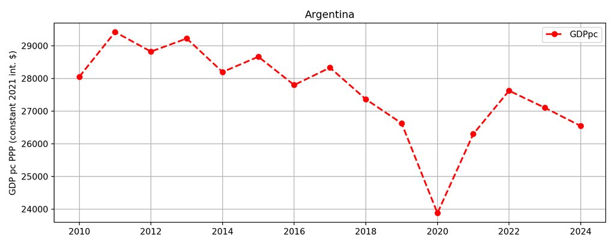

```python
import matplotlib.pyplot as plt

AR = df.loc[:, ('ccode', 'year', 'gdp_pc2021')]
AR = AR[AR.ccode == 'ARG']

plt.figure(figsize=(10, 4))
plt.plot(AR.year, AR.gdp_pc2021, color='red', linestyle='--', linewidth=2, marker='o', label='GDPpc')
plt.xlabel('')
plt.ylabel('GDP pc PPP (constant 2021 int. $)')
plt.title('Argentina')
plt.grid(True)
plt.legend()
plt.tight_layout()
plt.show()
```

```python
plt.savefig('arg_gdp.png')
```